# PROJET DE MODELISATION STATISTIQUE DE PRIX DE VOITURES DE FABRICATION AMERICAINE SUR LE MARCHE DES ETATS-UNIS

Mohamed Falilou Fall

2024-07-17

Les variables: “Km” (kilométrage du véhicule), “Marque” (marque du véhicule), “Modèle” (modèle du véhicule), “Sous-modèle” (varient selon les options), “Type” (de carrosserie), “Cylindré” (moteur), “Litre” (mesure plus précise de la taille du moteur), “Portes” (Nombre de portes), “Régulateur”, “HP” (haut-parleurs Dolby stéréo), “Cuir” (intérieur cuir).

Les Marques, “Buick” , “Cadillac” , “Chevrolet” , “Pontiac” , “Saturn”, sont de fabrication americaine. La marque “SAAB” est de fabrication suedoise.

# 1- Le DataFrame

## 1-1 Affichage des 7 premieres lignes du DataFrame

```r
head(Base_Projet_Introduction_Modelisation_2024,7)
```

| Prix | Km | Marque | Modèle | Sous-modèle | Type | Cylindrée | Litre | Portes | Régulateur | HP | Cuir |
| --- | --- | --- | --- | --- | --- | --- | --- | --- | --- | --- | --- |
| 17314.10 | 8221 | Buick | Century | Sedan 4D | Sedan | 6 | 3.1 | 4 | 1 | 1 | 1 |
| 17542.04 | 9135 | Buick | Century | Sedan 4D | Sedan | 6 | 3.1 | 4 | 1 | 1 | 0 |
| 16218.85 | 13196 | Buick | Century | Sedan 4D | Sedan | 6 | 3.1 | 4 | 1 | 1 | 0 |
| 16336.91 | 16342 | Buick | Century | Sedan 4D | Sedan | 6 | 3.1 | 4 | 1 | 0 | 0 |
| 16339.17 | 19832 | Buick | Century | Sedan 4D | Sedan | 6 | 3.1 | 4 | 1 | 0 | 1 |
| 15709.05 | 22236 | Buick | Century | Sedan 4D | Sedan | 6 | 3.1 | 4 | 1 | 1 | 0 |
| 15230.00 | 22576 | Buick | Century | Sedan 4D | Sedan | 6 | 3.1 | 4 | 1 | 1 | 0 |

## 1-2 Informations tirees du DataFrame

```r
# La dimension du DataFrame (804 voitures et 12 variables)
dim(Base_Projet_Introduction_Modelisation_2024)
```

```
[1] 804  12
```

```r
# Les Marques de voitures et leurs frequences
frequence_marque <- table(Base_Projet_Introduction_Modelisation_2024$Marque)
print(frequence_marque)
```

```
    Buick  Cadillac Chevrolet   Pontiac      SAAB    Saturn
       80        80       320       150       114        60
```

```r
# Compte des Modèles de voitures et leurs frequences
frequence_modele <- table(Base_Projet_Introduction_Modelisation_2024$Modèle)
print(frequence_modele)
```

```
   9-2X AWD         9_3      9_3 HO         9_5      9_5 HO        AVEO
          4          20          40          30          20          60
 Bonneville    Cavalier     Century     Classic      Cobalt    Corvette
         30          60          10          10          50          20
      CST-V         CTS     Deville          G6    Grand Am  Grand Prix
         10          10          30          20          20          30
        GTO      Impala         Ion    L Series    Lacrosse     Lesabre
         10          30          50          10          30          20
     Malibu Monte Carlo Park Avenue      STS-V6      STS-V8     Sunfire
         60          30          20          10          10          10
       Vibe      XLR-V8
         30          10
```

```r
# `Valeure minimale d'une voiture = 5.182.840  F CFA`
# `Valeure maximale d'une voiture = 42.449.034 F CFA`

prix_minimal <- min(Base_Projet_Introduction_Modelisation_2024$Prix)
prix_maximal <- max(Base_Projet_Introduction_Modelisation_2024$Prix)



print(paste("Le prix minimal en $ d'une voiture de marque americaine est egal a:", prix_minimal, ", "  ,"soit:", 599.94 * prix_minimal, "F CFA"))
```

```
[1] "Le prix minimal en $ d'une voiture de marque americaine est egal a: 8638.93089526066 ,  soit: 5182840.20130268 F CFA"
```

```r
print(paste("Le prix maximal en $ d'une voiture de marque americaine est egal a:", prix_maximal, ", "  ,"soit:", 599.94 * prix_maximal, "F CFA"))
```

```
[1] "Le prix maximal en $ d'une voiture de marque americaine est egal a: 70755.4667165429 ,  soit: 42449034.7019227 F CFA"
```

# 2- Identification des 3 variables les plus corrélées à la variable dépendante Prix.

## 2-1 - Seperation des variables numeriques `num_vars` des variables categorielles `cat_vars`

```r
num_vars <- Base_Projet_Introduction_Modelisation_2024[, sapply(Base_Projet_Introduction_Modelisation_2024, is.numeric)]

cat_vars <- Base_Projet_Introduction_Modelisation_2024[, sapply(Base_Projet_Introduction_Modelisation_2024, is.factor) | sapply(df, is.character)]
```

## 2-2 Afichage de la base de donnees des variables numeriques `num_vars`

```r
head(num_vars,7)
```

| Prix | Km | Cylindrée | Litre | Portes | Régulateur | HP | Cuir |
| --- | --- | --- | --- | --- | --- | --- | --- |
| 17314.10 | 8221 | 6 | 3.1 | 4 | 1 | 1 | 1 |
| 17542.04 | 9135 | 6 | 3.1 | 4 | 1 | 1 | 0 |
| 16218.85 | 13196 | 6 | 3.1 | 4 | 1 | 1 | 0 |
| 16336.91 | 16342 | 6 | 3.1 | 4 | 1 | 0 | 0 |
| 16339.17 | 19832 | 6 | 3.1 | 4 | 1 | 0 | 1 |
| 15709.05 | 22236 | 6 | 3.1 | 4 | 1 | 1 | 0 |
| 15230.00 | 22576 | 6 | 3.1 | 4 | 1 | 1 | 0 |

## 2-3 Correlation entre les variables numeriques `num_vars`

```r
correlations <- cor(num_vars)
correlations
```

```
                 Prix           Km   Cylindrée       Litre      Portes
Prix        1.0000000 -0.143050506  0.56908614  0.55814581 -0.13874965
Km         -0.1430505  1.000000000 -0.02946099 -0.01864062 -0.01694449
Cylindrée   0.5690861 -0.029460989  1.00000000  0.95789658  0.00220592
Litre       0.5581458 -0.018640622  0.95789658  1.00000000 -0.07925909
Portes     -0.1387497 -0.016944490  0.00220592 -0.07925909  1.00000000
Régulateur  0.4308515  0.025036652  0.35428485  0.37750927 -0.04767418
HP         -0.1243478 -0.026145926 -0.08970430 -0.06552707 -0.06253031
Cuir        0.1571969  0.001005446  0.07551962  0.08733194 -0.06196858
            Régulateur          HP         Cuir
Prix        0.43085149 -0.12434785  0.157196855
Km          0.02503665 -0.02614593  0.001005446
Cylindrée   0.35428485 -0.08970430  0.075519616
Litre       0.37750927 -0.06552707  0.087331945
Portes     -0.04767418 -0.06253031 -0.061968579
Régulateur  1.00000000 -0.09173015 -0.070573094
HP         -0.09173015  1.00000000  0.165443625
Cuir       -0.07057309  0.16544362  1.000000000
```

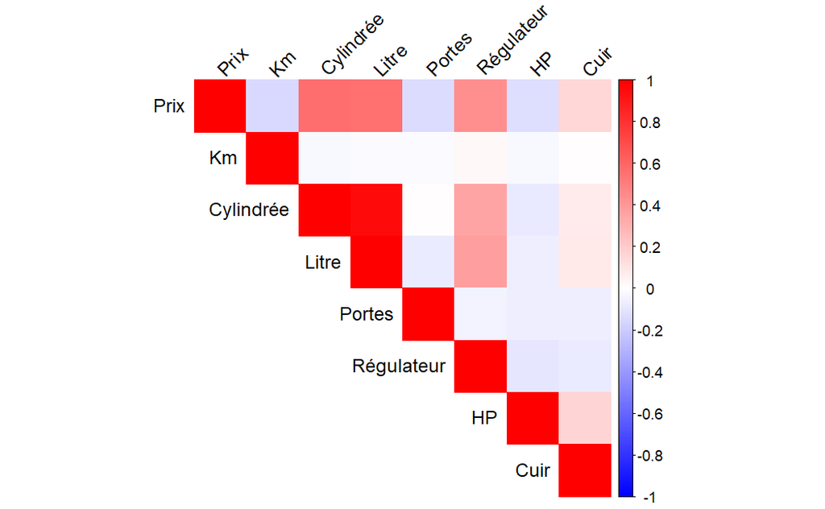

```r
# Heatmap Correlation entre les variables numeriques `num_vars`

library(corrplot)
corrplot(correlations, method = "color", type = "upper",
         tl.col = "black", tl.srt = 45,
         col = colorRampPalette(c("blue", "white", "red"))(200))
```

## 2-4 Extraction de la variable dependante `Prix`

```r
dependante_var <- "Prix"
dependante_var
```

```
[1] "Prix"
```

## 2-5 Extraction des corrélations avec la variable dépendante `Prix`

```r
cor_avec_prix <- correlations[, dependante_var]
cor_avec_prix
```

```
      Prix         Km  Cylindrée      Litre     Portes Régulateur         HP
 1.0000000 -0.1430505  0.5690861  0.5581458 -0.1387497  0.4308515 -0.1243478
      Cuir
 0.1571969
```

## 2-7 Tri par ordre des corrélations avec la variable dépendante `Prix`

```r
tri_correlations <- sort(abs(cor_avec_prix), decreasing = TRUE)
tri_correlations
```

```
      Prix  Cylindrée      Litre Régulateur       Cuir         Km     Portes
 1.0000000  0.5690861  0.5581458  0.4308515  0.1571969  0.1430505  0.1387497
        HP
 0.1243478
```

## Interpretation :

**Les 3 variables les plus corrélées à la variable dépendante `Prix` sont `Cylindrée`, `Litre` et `Régulateur`**

# 3 - Mise en place de 3 modèles de régression linéaire simple et Comparaisons des modèles

## 3-1 Ajustement du modèle de régression linéaire `Prix`, `Cylindrée`: le `model1`

```r
model1 <- lm(Prix ~ Cylindrée, data = num_vars)
summary(model1)
```

```
Call:
lm(formula = Prix ~ Cylindrée, data = num_vars)

Residuals:
   Min     1Q Median     3Q    Max
-11216  -5230  -2749   2773  38339

Coefficients:
            Estimate Std. Error t value Pr(>|t|)
(Intercept)   -17.06    1126.94  -0.015    0.988
Cylindrée    4054.20     206.85  19.600   <2e-16 ***
---
Signif. codes:  0 ‘***’ 0.001 ‘**’ 0.01 ‘*’ 0.05 ‘.’ 0.1 ‘ ’ 1

Residual standard error: 8133 on 802 degrees of freedom
Multiple R-squared:  0.3239,    Adjusted R-squared:  0.323
F-statistic: 384.1 on 1 and 802 DF,  p-value: < 2.2e-16
```

### - Tracé des données du `Model1`

```r
p <- ggplot(num_vars, aes(x = Prix, y = Cylindrée)) +
  geom_point() +
  geom_smooth(method = "lm", se = FALSE) +
  labs(title = "Régression linéaire interactive entre Prix et Cylindrée", x = "Prix", y = "Cylindrée")
p_interactif1 <- ggplotly(p)
p_interactif1
```

[output not shown]

## 3-2 Ajustement du modèle de régression linéaire `Prix`, `Litre`: le `model2`

```r
model2 <- lm(Prix ~ Litre, data = num_vars)
summary(model2)
```

```
Call:
lm(formula = Prix ~ Litre, data = num_vars)

Residuals:
   Min     1Q Median     3Q    Max
-10186  -5128  -3172   3032  41614

Coefficients:
            Estimate Std. Error t value Pr(>|t|)
(Intercept)   6185.8      846.7   7.306 6.66e-13 ***
Litre         4990.4      262.0  19.050  < 2e-16 ***
---
Signif. codes:  0 ‘***’ 0.001 ‘**’ 0.01 ‘*’ 0.05 ‘.’ 0.1 ‘ ’ 1

Residual standard error: 8207 on 802 degrees of freedom
Multiple R-squared:  0.3115,    Adjusted R-squared:  0.3107
F-statistic: 362.9 on 1 and 802 DF,  p-value: < 2.2e-16
```

### - Tracé des donnees du `Model2`

```r
p <- ggplot(num_vars, aes(x = Prix, y = Litre)) +
  geom_point() +
  geom_smooth(method = "lm", se = FALSE) +
  labs(title = "Régression linéaire interactive entre Prix et Litre", x = "Prix", y = "Litre")
p_interactif2 <- ggplotly(p)
p_interactif2
```

[output not shown]

## 3-3 Ajustement du modèle de régression linéaire `Prix`, `Régulateur`: le `model3`

```r
model3 <- lm(Prix ~ Régulateur, data = num_vars)
summary(model3)
```

```
Call:
lm(formula = Prix ~ Régulateur, data = num_vars)

Residuals:
   Min     1Q Median     3Q    Max
-14913  -6020  -1454   3634  46971

Coefficients:
            Estimate Std. Error t value Pr(>|t|)
(Intercept)  13921.9      632.7   22.00   <2e-16 ***
Régulateur    9862.3      729.4   13.52   <2e-16 ***
---
Signif. codes:  0 ‘***’ 0.001 ‘**’ 0.01 ‘*’ 0.05 ‘.’ 0.1 ‘ ’ 1

Residual standard error: 8926 on 802 degrees of freedom
Multiple R-squared:  0.1856,    Adjusted R-squared:  0.1846
F-statistic: 182.8 on 1 and 802 DF,  p-value: < 2.2e-16
```

### - Tracé des donnees du `Model3`

```r
p <- ggplot(num_vars, aes(x = Prix, y = Régulateur)) +
  geom_point() +
  geom_smooth(method = "lm", se = FALSE) +
  labs(title = "Régression linéaire interactive entre Prix et Régulateur", x = "Prix", y = "Régulateur")
p_interactif3 <- ggplotly(p)
p_interactif3
```

[output not shown]

## 3-4 Comparaison des 3 models( `model1`, `model2`, `model3`)

### 3-4-1 Comparaison des `R-squared (R²)` , `Adjusted R-squared` , `AIC` , `BIC` , `Coefficients` , `p-value`

```r
# Extraction des informations importantes pour la comparaison

models <- list(model1, model2, model3)
noms_models <- c("Model1 (Prix ~ Cylindrée)", "Model2 (Prix ~ Litre)", "Model3 (Prix ~ Régulateur)")

resultats_compares <- data.frame(
  Model = noms_models,
  R_squared = sapply(models, function(model) summary(model)$r.squared),
  Adjusted_R_squared = sapply(models, function(model) summary(model)$adj.r.squared),
  AIC = sapply(models, AIC),
  BIC = sapply(models, BIC),
  p_value = sapply(models, function(model) anova(model)$`Pr(>F)`[1])
)

print(resultats_compares)
```

| Model | R_squared | Adjusted_R_squared | AIC | BIC | p_value |
| --- | --- | --- | --- | --- | --- |
| Model1 (Prix ~ Cylindrée) | 0.3238590 | 0.3230160 | 16763.61 | 16777.68 | 3.454261e-70 |
| Model2 (Prix ~ Litre) | 0.3115267 | 0.3106683 | 16778.14 | 16792.21 | 4.948812e-67 |
| Model3 (Prix ~ Régulateur) | 0.1856330 | 0.1846176 | 16913.16 | 16927.23 | 1.127033e-37 |

```r
NA
```

## Interpretation:

- Le `R_Squared` : La proportion de la variance totale des données qui est expliquée par le `modèle1` est plus elevé que ceux des 2 autres models. Plus le `R-squared` est élevé, meilleur est l’ajustement du modèle aux données. Donc le `model1` est le meilleur model si nous nous basons uniquement sur le `R_Squared`.
- `Adjusted_R_squared` : La valeure de l’`Adjusted R-squared` du `model1` indique un meilleur ajustement du modèle aux données car etant plus eleve. Donc le `model1` est le meilleur model si nous nous basons uniquement sur l’`Adjusted_R_squared`.
- Le `model1` a la plus petite valeur d’`AIC` (Akaike Information Criterion) donc il est le meilleur model.
- Le `BIC` (Bayesian Information Criteria) du `model1` est plus bas que celui des 2 autres donc nous choisisons le `model1`.
- Le `model1` a un variable prédictive `Cylindrée` ayant un p-value significativement faible et est considéré comme le meilleur car il indique une meilleure adéquation du variable `Cylindrée` utilisée pour expliquer la variable `Prix`

### 3-4-2 Visualisation des residus

```r
# Le Tracé des résidus vs les valeurs ajustées pour chaque modèle

par(mfrow = c(1, 3))  # Disposition des graphiques en une ligne et trois colonnes

plot(model1$fitted.values, model1$residuals, main = "Model1 (Prix ~ Cylindrée)",
     xlab = "Valeurs ajustées", ylab = "Résidus")
abline(h = 0, col = "red")
```

```r
plot(model2$fitted.values, model2$residuals, main = "Model2 (Prix ~ Litre)",
     xlab = "Valeurs ajustées", ylab = "Résidus")
abline(h = 0, col = "red")
```

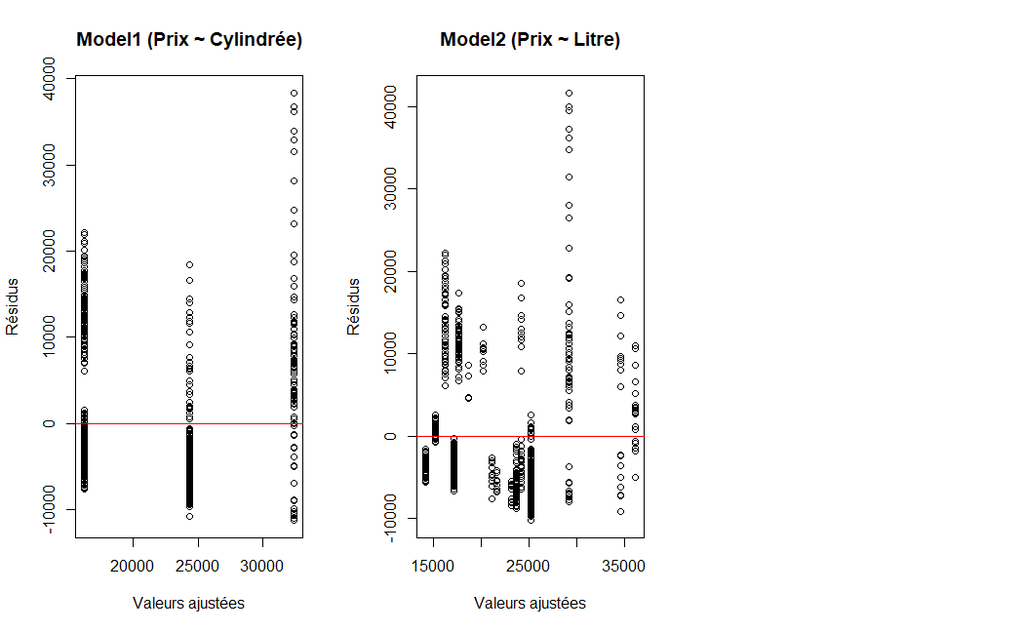

```r
plot(model3$fitted.values, model3$residuals, main = "Model3 (Prix ~ Régulateur)",
     xlab = "Valeurs ajustées", ylab = "Résidus")
abline(h = 0, col = "red")
```

[output not shown]

# 4 - Analyse multivariée pour décrire le processus d’attribution du Prix d’un véhicule en fonction des caractéristiques quantitatives.

## 4-1 Régression linéaire multiple (Interpretation du model)

### 4-1-1 Analyse du `summary` du model de regression multiple

```r
model_reg_multiple <- lm(Prix ~ Km + Cylindrée + Litre + Portes + Régulateur + HP + Cuir, data = num_vars)

summary(model_reg_multiple)
```

```
Call:
lm(formula = Prix ~ Km + Cylindrée + Litre + Portes + Régulateur +
    HP + Cuir, data = num_vars)

Residuals:
   Min     1Q Median     3Q    Max
-13278  -5615  -1556   3996  32819

Coefficients:
              Estimate Std. Error t value Pr(>|t|)
(Intercept)  6.759e+03  1.877e+03   3.601 0.000337 ***
Km          -1.698e-01  3.187e-02  -5.326 1.31e-07 ***
Cylindrée    3.792e+03  6.832e+02   5.551 3.87e-08 ***
Litre       -7.872e+02  8.671e+02  -0.908 0.364196
Portes      -1.543e+03  3.205e+02  -4.814 1.77e-06 ***
Régulateur   6.289e+03  6.580e+02   9.558  < 2e-16 ***
HP          -1.994e+03  5.718e+02  -3.487 0.000515 ***
Cuir         3.349e+03  5.977e+02   5.604 2.89e-08 ***
---
Signif. codes:  0 ‘***’ 0.001 ‘**’ 0.01 ‘*’ 0.05 ‘.’ 0.1 ‘ ’ 1

Residual standard error: 7388 on 796 degrees of freedom
Multiple R-squared:  0.4463,    Adjusted R-squared:  0.4414
F-statistic: 91.64 on 7 and 796 DF,  p-value: < 2.2e-16
```

## Analyse:

2 - `Les codes de significativité` : d’apres les codes, les coefficients sont tous significatifs avec 3 etoiles ( `***` ) sauf pour la variale `Litre`

### 4-1-2 Graphique des residus

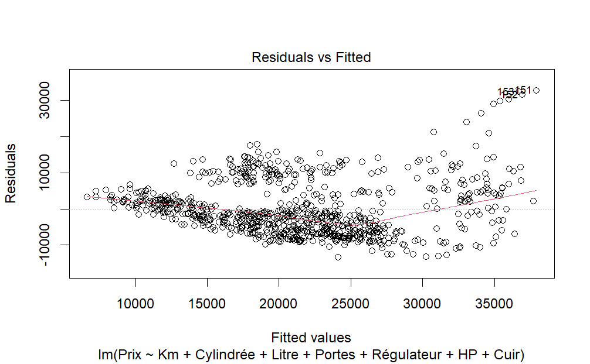

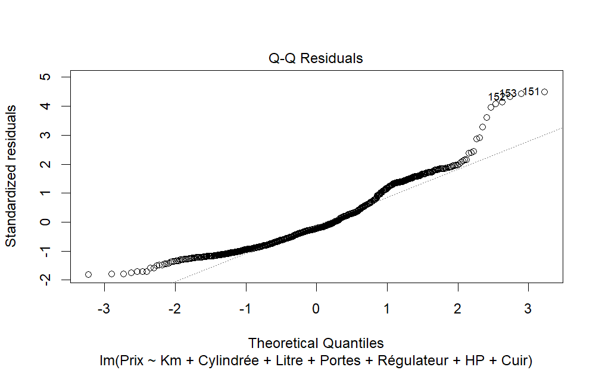

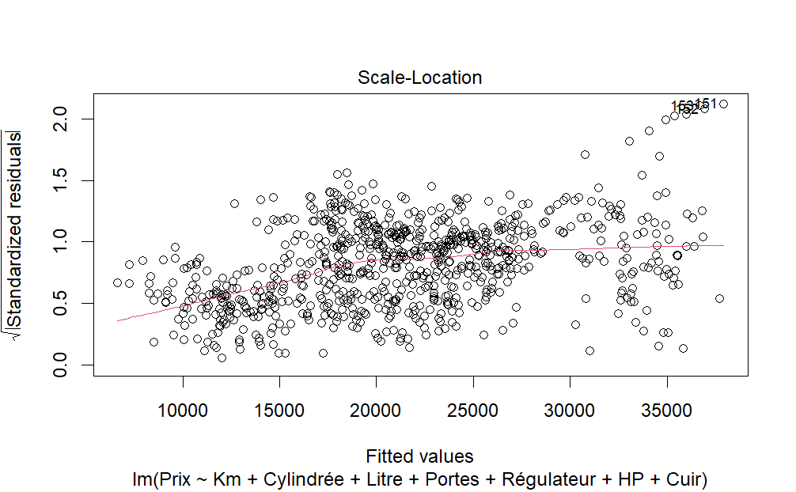

```r
plot(model_reg_multiple)
```

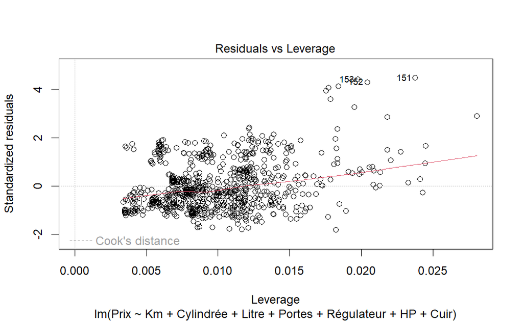

```r
NA
```

### 4-1-2 Test de normalité des résidus

```r
shapiro.test(resid(model_reg_multiple))
```

```
    Shapiro-Wilk normality test

data:  resid(model_reg_multiple)
W = 0.92927, p-value < 2.2e-16
```

## Interpretation :

[output not shown]

## 5-2 Application Shiny de prédiction de `Prix` basée sur la `Cylindrée` de la voiture (Script de l’App)

```r
library(shiny)

# Définition de l'interface utilisateurs
ui <- fluidPage(
  titlePanel("APPLICATION DE PREDICTION DE PRIX DE VOITURES DE FABRICATION AMERICAINE SUR LE MARCHE DES ETATS-UNIS SELON LE NOMBRE DE CYLINDRES"),
  sidebarLayout(
    sidebarPanel(
      sliderInput("Cylindrée", "Cylindrée",
                  min = min(num_vars$Cylindrée), max = max(num_vars$Cylindrée),
                  value = median(num_vars$Cylindrée))
    ),
    mainPanel(
      textOutput("prediction"),
      plotOutput("plot")
    )
  )
)

# Définition de la logique serveur
server <- function(input, output) {
  # Faire des prédictions basées sur l'entrée de l'utilisateur
  output$prediction <- renderText({
    new_data <- data.frame(Cylindrée = input$Cylindrée)
    predicted_Prix <- predict(model1, new_data)
    paste("Le Prix prédit en Dollars est de", round(predicted_Prix, 2), "$")
  })

  # Créer un graphique de la régression
  output$plot <- renderPlot({
    plot(num_vars$Cylindrée, num_vars$Prix,
         xlab = "Puissance du moteur", ylab = "Prix en $",
         main = "Régression linéaire")
    abline(model1, col = "blue")
    points(input$Cylindrée, predict(model1, data.frame(Cylindrée = input$Cylindrée)), col = "red", pch = 17)
  })
}

# Lancement de l'application
shinyApp(ui = ui, server = server)
```